# R Notebook

## Post processing

### Log-posterior

[figure not shown]

Need to update the Rhat functions first to use the plot_alpha_posterior function

```r
# fit$K <- K
# fit$alpha_hat <- alpha_hat
# plot_alpha_posterior(fit, facet_trace = T)
```

```r
alpha-
apply(fit$mcmc_chains[[chain]]$alpha_out_thin, c(1, 2), mean)
```

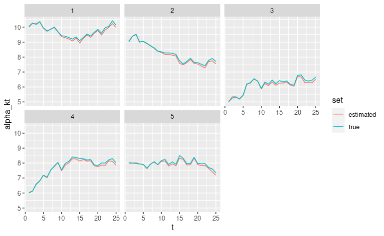

```r
bind_rows(list(true = data.frame(cbind(k = c(1:K), alpha)), estimated = data.frame(cbind(k = 1:K, apply(fit$mcmc_chains[[chain]]$alpha_out_thin, c(1, 2), mean)))), .id = "set") %>%
  pivot_longer(cols = starts_with("V"), names_to = "t", values_to = "alpha_kt") %>%
  mutate(t = as.numeric(str_replace(t, "V", "")) - 1) %>%
  mutate(set_k = str_c(set, k)) %>%
  ggplot() +
  geom_line(aes(t, alpha_kt, group = set_k, colour = set)) +
  facet_wrap(~k, scales = "fixed")
```

[output not shown]

## Acceptance rates

alpha:

```r
fit$mcmc_chains[[chain]]$alpha_acc_mean
```

```
        [,1]   [,2]   [,3]   [,4]   [,5]   [,6]   [,7]   [,8]   [,9]  [,10]  [,11]  [,12]  [,13]  [,14]  [,15]  [,16]  [,17]  [,18]  [,19]
 [1,] 0.3075 0.3109 0.2609 0.3401 0.3551 0.3615 0.2590 0.3780 0.2502 0.3634 0.2476 0.2581 0.3635 0.3093 0.2158 0.2332 0.2497 0.3781 0.2872
 [2,] 0.2887 0.3500 0.2414 0.2623 0.3305 0.2217 0.3062 0.2539 0.3480 0.2563 0.2366 0.2163 0.3270 0.2124 0.2550 0.2886 0.3173 0.3419 0.3340
 [3,] 0.2696 0.3614 0.3223 0.3386 0.2548 0.3329 0.2588 0.2327 0.2029 0.2585 0.1992 0.1181 0.0574 0.0355 0.0290 0.0171 0.0108 0.0168 0.0135
 [4,] 0.2847 0.2664 0.2139 0.3390 0.2453 0.3155 0.3115 0.2121 0.2364 0.3365 0.3334 0.3774 0.3194 0.2368 0.2765 0.2488 0.3318 0.3394 0.2549
 [5,] 0.3128 0.2820 0.3147 0.2166 0.2553 0.3277 0.3369 0.2947 0.2793 0.2920 0.3055 0.3651 0.2929 0.2772 0.2507 0.2106 0.3596 0.3482 0.2972
 [6,] 0.3220 0.3420 0.3529 0.3104 0.3137 0.3461 0.3046 0.2988 0.2851 0.3531 0.2648 0.3563 0.3339 0.2598 0.3336 0.2572 0.2848 0.2648 0.3699
 [7,] 0.2978 0.3667 0.3521 0.2934 0.3593 0.2293 0.2390 0.3184 0.3188 0.2579 0.2283 0.2861 0.2294 0.3148 0.3477 0.2459 0.3063 0.2745 0.2862
 [8,] 0.2649 0.2737 0.3081 0.3175 0.2575 0.2778 0.3869 0.3404 0.2935 0.2521 0.2506 0.3168 0.2543 0.3509 0.3124 0.2597 0.3607 0.2309 0.3181
 [9,] 0.2737 0.3608 0.2671 0.3720 0.2927 0.3248 0.3398 0.2396 0.2505 0.2862 0.3174 0.3341 0.3499 0.3287 0.2853 0.3105 0.3778 0.3641 0.3240
[10,] 0.2981 0.2883 0.2139 0.2549 0.2109 0.3547 0.2260 0.2690 0.2764 0.2369 0.2112 0.2470 0.3238 0.3718 0.2604 0.3712 0.2320 0.3104 0.3387
[11,] 0.2606 0.3876 0.2449 0.3482 0.2386 0.3487 0.3157 0.2790 0.2822 0.3207 0.2219 0.3553 0.3698 0.3285 0.3662 0.3065 0.2661 0.2596 0.2426
[12,] 0.3547 0.3007 0.3620 0.3373 0.3276 0.3016 0.3101 0.3267 0.2490 0.2580 0.2827 0.2794 0.2962 0.2769 0.3021 0.2563 0.3236 0.2759 0.3243
[13,] 0.3596 0.2532 0.2523 0.2748 0.3013 0.2253 0.3435 0.2869 0.3586 0.3654 0.3399 0.3529 0.3661 0.3498 0.3270 0.2718 0.3315 0.2889 0.2790
[14,] 0.2708 0.2706 0.2789 0.3240 0.3306 0.2851 0.2340 0.2417 0.3841 0.2275 0.3460 0.2807 0.3092 0.3787 0.3015 0.2712 0.2757 0.2573 0.2580
```

[output cut: 37 more lines]

$Z_t$:

```r
fit$mcmc_chains[[chain]]$Z_acc_mean %>% round(2)
```

```
      [,1] [,2] [,3] [,4] [,5] [,6]
 [1,] 0.35 0.27 0.25 0.28 0.36 0.32
 [2,] 0.35 0.36 0.32 0.30 0.27 0.31
 [3,] 0.35 0.25 0.28 0.24 0.27 0.31
 [4,] 0.34 0.32 0.27 0.21 0.38 0.22
 [5,] 0.25 0.28 0.24 0.25 0.38 0.35
 [6,] 0.24 0.30 0.29 0.22 0.44 0.35
 [7,] 0.25 0.37 0.31 0.27 0.24 0.24
 [8,] 0.33 0.32 0.37 0.26 0.26 0.25
 [9,] 0.28 0.31 0.25 0.30 0.25 0.34
[10,] 0.29 0.25 0.25 0.33 0.37 0.21
[11,] 0.35 0.28 0.24 0.22 0.28 0.33
[12,] 0.27 0.36 0.28 0.26 0.25 0.30
[13,] 0.27 0.25 0.31 0.37 0.31 0.34
[14,] 0.37 0.24 0.37 0.31 0.26 0.37
[15,] 0.27 0.27 0.29 0.31 0.29 0.29
[16,] 0.27 0.34 0.31 0.30 0.39 0.25
[17,] 0.28 0.39 0.38 0.27 0.25 0.24
[18,] 0.37 0.23 0.29 0.25 0.31 0.28
[19,] 0.28 0.26 0.29 0.29 0.32 0.29
[20,] 0.28 0.34 0.28 0.25 0.32 0.33
[21,] 0.27 0.34 0.32 0.35 0.28 0.27
[22,] 0.32 0.29 0.31 0.33 0.29 0.28
[23,] 0.33 0.24 0.30 0.25 0.31 0.29
[24,] 0.30 0.30 0.21 0.27 0.28 0.34
[25,] 0.35 0.23 0.29 0.33 0.24 0.28
```

## Estimated latent positions

Procrustes correlation for each time point:

```r
walk(1:TT, function(t) print(paste0("t = ", t, ": ", round(vegan::protest(Z[ , , t], fit$Z_hat_t[ , , t])$t0, 3))))
```

```
[1] "t = 1: 0.998"
[1] "t = 2: 0.999"
[1] "t = 3: 0.999"
[1] "t = 4: 1"
[1] "t = 5: 0.999"
[1] "t = 6: 0.998"
[1] "t = 7: 0.999"
[1] "t = 8: 0.999"
[1] "t = 9: 0.999"
[1] "t = 10: 0.999"
[1] "t = 11: 0.999"
[1] "t = 12: 0.999"
[1] "t = 13: 0.999"
[1] "t = 14: 0.998"
[1] "t = 15: 0.998"
[1] "t = 16: 0.999"
[1] "t = 17: 0.999"
[1] "t = 18: 0.998"
[1] "t = 19: 0.997"
[1] "t = 20: 0.998"
[1] "t = 21: 0.999"
[1] "t = 22: 0.999"
[1] "t = 23: 0.999"
[1] "t = 24: 0.999"
[1] "t = 25: 0.999"
```

```r
# Procrustes correlation of the stacked matrices:
# (first I need to take the posterior mean of the stacked and transformed samples, the Z_trans matrix was already made above)
Z_trans_mean <- matrix(NA, nrow = dim(fit$Z_trans)[1], ncol = dim(fit$Z_trans)[2])
for(i in 1:(n*TT)) {
  for(j in 1:2) {
    Z_trans_mean[i, j] <- mean(fit$Z_trans[i, j, ])
  }
}

# Construct stacked matrix of the true Z matrices:
Z_stack_true <- matrix(NA, nrow = n*TT, ncol = d)
for(t in 1:TT) {
  Z_stack_true[((t - 1)*n + 1):(t*n), ] <- Z[ , , t] # These indexes look weird but they are correct:
}

# Compare to the stacked true matrices:
paste0("Correlation of stacked matrices (nT x 2): ", round(vegan::protest(Z_stack_true, Z_trans_mean)$t0, 3))
```

```
[1] "Correlation of stacked matrices (nT x 2): 0.998"
```

This is the true node trajectories compared to the posterior estimates after Procrustes transformation using the true values as reference: (the same “stacking” method is used again here)

[interactive chart not shown]

TODO: Add the comaprison of time points and layers using the code above where I generate the data and this code for the comparison.

[output not shown]

# Example 2: using Sewell init

```r
library(dmlpm)
Z_0_sewell <- initialise_Z(Y, d = 2)
```

[interactive chart not shown]

```
[1] 0.956
[1] 0.96
[1] 0.957
[1] 0.955
[1] 0.957
[1] 0.961
[1] 0.962
[1] 0.965
[1] 0.966
[1] 0.965
[1] 0.968
[1] 0.973
[1] 0.977
[1] 0.977
[1] 0.981
[1] 0.984
[1] 0.984
[1] 0.982
[1] 0.98
[1] 0.98
[1] 0.981
[1] 0.982
[1] 0.983
[1] 0.981
[1] 0.982
```

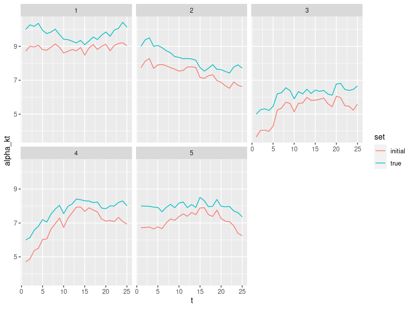